# Определение возраста по фото

Сетевой супермаркет внедряет систему компьютерного зрения для обработки фотографий покупателей. Фотофиксация в прикассовой зоне поможет определять возраст клиентов, чтобы:

- Анализировать покупки и предлагать товары, которые могут заинтересовать покупателей этой возрастной группы;
- Контролировать добросовестность кассиров при продаже алкоголя.

**Задача:** определять приблизительный возраст человека по фотографии с помощью свёрточной нейронной сети.  
*Требование к качеству модели*: ошибка предсказания возраста, оцененная по MAE, не должна превышать 8 лет.

**Описание данных**  
Набор фотографий людей с указанием возраста. Данные взяты с сайта [ChaLearn Looking at People](https://chalearnlap.cvc.uab.cat/dataset/26/description/).  
Имеется папка со всеми изображениями (path/final_files) и CSV-файл labels.csv с двумя колонками:

- file_name - имя файла фото;
- real_age - реальный возраст людей на фото в годах.

# Содержание

```python
# Importing Libraries
import random
import warnings
warnings.filterwarnings('ignore')

import matplotlib.pyplot as plt
import numpy as np
import pandas as pd

from tensorflow.keras.preprocessing.image import ImageDataGenerator
```

## Исследовательский анализ данных

- **возраст на фото**

Загрузим значения реального возраста людей на фотографиях.

```python
# Downloading dataframe with labels
labels = pd.read_csv('/datasets/faces/labels.csv')

# get first rows
labels.head()
```

|  | file_name | real_age |
| --- | --- | --- |
| 0 | 000000.jpg | 4 |
| 1 | 000001.jpg | 18 |
| 2 | 000002.jpg | 80 |
| 3 | 000003.jpg | 50 |
| 4 | 000004.jpg | 17 |

```python
# get information about the data
labels.info()
```

```
<class 'pandas.core.frame.DataFrame'>
RangeIndex: 7591 entries, 0 to 7590
Data columns (total 2 columns):
 #   Column     Non-Null Count  Dtype
---  ------     --------------  -----
 0   file_name  7591 non-null   object
 1   real_age   7591 non-null   int64
dtypes: int64(1), object(1)
memory usage: 118.7+ KB
```

Файл с метками содержит 7591 имя файла фотографии и соответствующий каждой фотографии реальный возраст человека в годах.

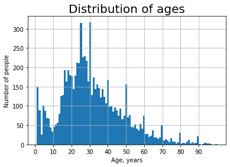

```
count    7591.000000
mean       31.201159
std        17.145060
min         1.000000
25%        20.000000
50%        29.000000
75%        41.000000
max       100.000000
Name: real_age, dtype: float64
```

```python
# Plotting the distribution of ages
labels['real_age'].hist(bins=100)
plt.title('Distribution of ages', fontsize=20)
plt.xticks(range(0, 100, 10))
plt.xlabel('Age, years')
plt.ylabel('Number of people')
plt.show()
labels['real_age'].describe()
```

- **фото**

Загрузим и посмотрим на сами фотографии.

```python
# Creating the ImageDataGenerator class
train_datagen = ImageDataGenerator(rescale=1./255)

# Downloading images, generating batches of normalized data
train_gen_flow = train_datagen.flow_from_dataframe(
        dataframe=labels,
        directory='/datasets/faces/final_files/',
        x_col='file_name',
        y_col='real_age',
        target_size=(224, 224),
        batch_size=32,
        class_mode='raw',
        shuffle=False,
        seed=123)
```

```
Found 7591 validated image filenames.
```

```python
# Number of batches
print(f'Number of batches: {len(train_gen_flow)}')
```

```
Number of batches: 238
```

```python
# Number of images in the last batch
print(f'Number of images in the last batch: {len(train_gen_flow[237][0])}')
```

```
Number of images in the last batch: 7
```

Из имеющегося датасета из 7591 фотографии получилось 238 батчей по 32 фотографии в каждом, кроме последнего, в него попало всего 7 фото.

Посмотрим на 12 случайных фото.

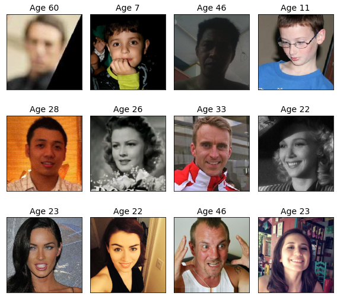

```python
# 12 random images with labels
fig = plt.figure(figsize=(8,8))
for i in range(1, 13):
    fig.add_subplot(3, 4, i)
    j = random.randrange(237)
    k = random.randrange(32)
    plt.imshow(train_gen_flow[j][0][k])
    plt.title(f'Age {train_gen_flow[j][1][k]}', fontsize=14)
    plt.xticks([])
    plt.yticks([])
    plt.tight_layout()
```

Кажется, что реальный возраст в общих чертах соответсвует фото. Среди фото попадают известные люди, актеры, астронавты, писатели (например, Алан Мур).

Ранее было обнаружено, что в данных есть крайние значения возраста, такие как 1 год и 100 лет. Покупателем в супермаркете вряд ли может быть малыш 1 года, но таких фото много, посмотрим соответсвуют ли фото крайним возрастам.

```python
print(f'Количество детей 1 года: {len(labels.query("real_age < 2"))}')
```

```
Количество детей 1 года: 149
```

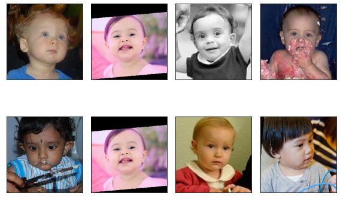

```python
# 8 random images of 1 year olds
fig = plt.figure(figsize=(8,8))
i=1
while i < 9:
    fig.add_subplot(2, 4, i)
    j = random.randrange(237)
    if (train_gen_flow[j][1] == 1).any():
        k = np.where(train_gen_flow[j][1] == 1)[0][0]
        plt.imshow(train_gen_flow[j][0][k])
        plt.xticks([])
        plt.yticks([])
        plt.tight_layout()
        i+=1
    else:
        i=i
```

Пожилых людей старше 90 лет совсем немного, посмотрим на их фотографии.

```python
print(f'Количество людей старше 92 лет: {len(labels.query("real_age > 92"))}')
```

```
Количество людей старше 92 лет: 12
```

```python
# batch numbers with photos of people over 92
n_batch_95plus = labels.query('real_age > 92').index // 32

# numbers of images of people over 92
n_image_95plus = labels.query('real_age > 92').index - n_batch_95plus*32
```

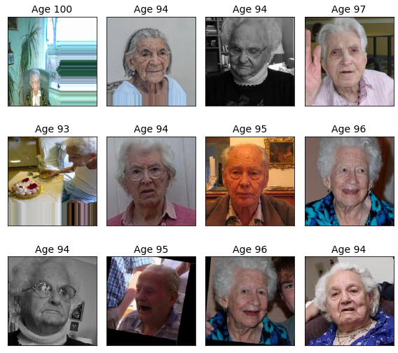

```python
# images of people over 92
fig = plt.figure(figsize=(8,8))
for i,j,k in zip(range(1, 13), n_batch_95plus, n_image_95plus):
    fig.add_subplot(3, 4, i)
    plt.imshow(train_gen_flow[j][0][k])
    plt.title(f'Age {train_gen_flow[j][1][k]}', fontsize=14)
    plt.xticks([])
    plt.yticks([])
    plt.tight_layout()
```

Фото малышей и пожилых людей визуально соответсвуют заявленному возрасту.

**Вывод:**

Имеющийся набор данных включает 7591 цветную фотографию людей разных возрастов, пола и рас. Большинство людей возраста до 40 лет (75%), средний возраст людей на снимках - около 30 лет. Минимальный возраст - 1 год, максимальный - 100 лет. Начиная с 30 лет, наблюдаются пики в количестве фото людей "круглого" возраста - 30, 40, 50 и тд. Кажется, также, что для малышам часто указывали возраст 1 год. Сложно представить, что дети в возрасте до 5 лет могут являться клиентами супермаркета, поэтому эту возрастную группу можно было бы исключить из анализа.

Исходя из визуализации данных видно, что к фотографиям уже была применена аугментация (сдвиги, повороты, возможно, отражения), поэтому можно изначально попробовать обучить модель без дополнительных аугментаций. Можно предположить, что модель будет скорее предсказывать возраст "пиков" в распределении возрастов.

## Обучение модели

Данных достаточно, чтобы попробовать использовать предобученную модель ResNet50 без замораживания базовых слоев модели.

```
import matplotlib.pyplot as plt
import numpy as np
import pandas as pd

from tensorflow.keras.applications.resnet import ResNet50
from tensorflow.keras.layers import Dense, GlobalAveragePooling2D
from tensorflow.keras.models import Sequential
from tensorflow.keras.optimizers import Adam
from tensorflow.keras.preprocessing.image import ImageDataGenerator

def load_train(path):
    # Downloading dataframe with labels
    labels = pd.read_csv(path+'labels.csv')

    # Creating the ImageDataGenerator class
    train_datagen = ImageDataGenerator(validation_split=0.25, rescale=1./255)

    # Downloading images, generating batches of normalized data
    train_gen_flow = train_datagen.flow_from_dataframe(
        dataframe=labels,
        directory=path+'final_files/',
        x_col='file_name',
        y_col='real_age',
        target_size=(224, 224),
        batch_size=32,
        class_mode='raw',
        subset='training',
        seed=123)

    return train_gen_flow

def load_test(path):
    # Downloading dataframe with labels
    labels = pd.read_csv(path+'labels.csv')

    # Creating the ImageDataGenerator class
    test_datagen = ImageDataGenerator(validation_split=0.25, rescale=1./255)

    # Downloading images, generating batches of normalized data
    test_gen_flow = test_datagen.flow_from_dataframe(
        dataframe=labels,
        directory=path+'final_files',
        x_col='file_name',
        y_col='real_age',
        target_size=(224, 224),
        batch_size=32,
        class_mode='raw',
        subset='validation',
        seed=123)

    return test_gen_flow

def create_model(input_shape):
    optimizer = Adam(lr=0.0002)

    backbone = ResNet50(input_shape=input_shape,
                        weights='imagenet',
                        include_top=False)

    model = Sequential()
    model.add(backbone)
    model.add(GlobalAveragePooling2D())
    model.add(Dense(1, activation='relu'))

    model.compile(loss='mean_absolute_error', optimizer=optimizer, metrics=['mean_absolute_error'])

    return model

def train_model(model, train_data, test_data, batch_size=None, epochs=5,
                steps_per_epoch=None, validation_steps=None):

    model.fit(train_data,
              validation_data=test_data,
              batch_size=batch_size, epochs=epochs,
              steps_per_epoch=steps_per_epoch,
              validation_steps=validation_steps,
              verbose=2)

    return model
```

```
Found 5694 validated image filenames.
Found 1897 validated image filenames.
Train for 178 steps, validate for 60 steps
Epoch 1/5
178/178 - 47s - loss: 10.6785 - mean_absolute_error: 10.6770 - val_loss: 22.4721 - val_mean_absolute_error: 22.3437
Epoch 2/5
178/178 - 39s - loss: 7.0618 - mean_absolute_error: 7.0604 - val_loss: 16.4337 - val_mean_absolute_error: 16.3103
Epoch 3/5
178/178 - 39s - loss: 6.1070 - mean_absolute_error: 6.1064 - val_loss: 17.5281 - val_mean_absolute_error: 17.4120
Epoch 4/5
178/178 - 37s - loss: 5.1399 - mean_absolute_error: 5.1391 - val_loss: 10.9634 - val_mean_absolute_error: 10.9521
Epoch 5/5
178/178 - 37s - loss: 4.6715 - mean_absolute_error: 4.6707 - val_loss: 6.9636 - val_mean_absolute_error: 6.9679
60/60 - 9s - loss: 6.9636 - mean_absolute_error: 6.9679
Test MAE: 6.9679
```

## Анализ обученной модели

На датасете из 7591 фотографии (25% из которых было зарезервировано под валидационную выборку) людей определенного возраста при использовании предобученой на ImageNet модели ResNet50 со скоростью обучения 0.0002 получилось на 5 эпохах получить предсказание возраста человека на фотографии с ошибкой около 7 лет (оценено по MAE). Обучение модели не заняло много времени.  
В качестве функции потерь также использовалась MAE, в качестве функции активации для последнего нейрона - нелинейная функция ReLU. Значение функции потерь на валидации заметно больше, чем на обучающей выборке, что говорит о переобучении модели.

С помощью построенной модели можно достаточно точно определять возраст человека, ошибка составляет менее 7 лет. Такой показатель можно считать частично приемлемый для задачи, так как позволит в целом определить возрастную группу покупателя для рекомендации товаров. В то же время, для контроля кассиров при продаже алкоголя данную модель стоит улучшить для уменьшения ошибки. Здесь было бы полезно исследовать, имеет ли модель тенденцию чаще ошибаться в большую или меньшую сторону, на каких возрастах. При тенденции к ошибке в большую сторону, эффект этого для задач данного проекта более негативный. Для заявленных целей можно попробовать исключить из данных детей младьше 10 лет, а оставшихся пользователей сгруппировать по возрасту, например, по 10 лет. Вероятность предсказания возрастной группы может быть точнее и быстрее. Проведя анализ ошибок, можно определить, на какой возрастной группе модель ошибается сильнее и добавить данных этой группы в выборку для дообучения.